# Precision of Northern Sea Otter Aging using Tooth Cementum Annuli Analysis

## 0.1 Introduction

For the last couple years, we have submitted multiple teeth from the same individual sea otter carcasses to Matson’s labs to assess precision of aging via cementum annuli analysis. In this document, I outline preliminary results of this exploratory investigation.

We submitted teeth from four general tooth type categories: Molars, Premolars, Canines, Incisors. These teeth originated from two regions: Katmai National Park and Western Prince William Sound.

### Sample Size of Aged Teeth by Predictor

| Molars | Premolars | Canines | Incisors |
| --- | --- | --- | --- |
| 31 | 65 | 30 | 29 |

| Katmai National Park | Western Prince William Sound |
| --- | --- |
| 120 | 39 |

| 2006 | 2007 | 2008 | 2013 | 2019 | 2021 | 2022 |
| --- | --- | --- | --- | --- | --- | --- |
| 2 | 6 | 6 | 6 | 23 | 22 | 94 |

## 0.2 Data Import and Cleaning

In the following code chunk, I import the raw dataset and undergo several cleaning steps including filtering out unknown tooth types, unsuccessfully aged teeth, and individuals with teeth aged in different years (i.e. recaptures).

```r
###############################################
# Part 0: Load packages #######################
###############################################

# Load packages
packages<- c("tidyverse", "readxl", "janitor", "lme4", "AICcmodavg", "viridis", "ggthemes")

pacman::p_load(packages, character.only = TRUE)


###############################################
# Part 1: Load raw dataset ####################
###############################################

SEOT_teeth_raw <- read_excel(here::here("data/raw/SEOT_teeth_raw.xlsx"))

###############################################
# Part 2: Clean and summarize datasets ########
###############################################

# Part 2A: Categorize tooth types (premolars, canines, incisors, molars, or unknown) ----
P <- c("P2a","P2b","P2","Pa","Pb","P","UP","LLP2","URP3","URP2","ULP3","ULP2","URP2 or ULP2","P2, additional tooth sent in 2023","LRP2","URP4")
C <- c("C","URC","LRC","ULC","ULC (BROKEN)")
I <- c("URI3","URI1","I3","ULI3","LLI2","LLI1","LRI2","UI1?","I2","UI2","LRI1")
M <- c("M","URM1","LRM1","ULM1","M2")
UNK <- c("UNK", "UNKa", "UNKb")


# Part 2B: Generate clean, single-tooth dataset ----------------------------------------
SEOT_teeth <- SEOT_teeth_raw %>%
  clean_names()%>%
#Remove individuals with no teeth collected and/or no ages calculated due to tooth damage
  filter(tooth_collected == "Y",
         otter_num != "SOD-2021-200", #individual with tooth damage (couldnt be aged)
         otter_num != "KEFJ-SOD-2014-01",#individual with certainty code missing
         otter_num != "SOD-2006-17/ capture otter SO-05-04",
         otter_num != "SOD-2007-02/capture otter SO-01-01", #teeth pulled different years
         otter_num != "SOD-2007-01/ capture otter SO-04-24", #teeth pulled different years
         otter_num != "WPWS-SOD-2014-02/ capture otter SO-2010-08" #teeth pulled different years
         ) %>%
#Categorize teeth to broad categories
  mutate(tooth_category =
           #categorize all unknown teeth as "UNK"
           case_when(tooth %in% UNK ~ "UNK",
                     tooth %in% C ~ "C",
                     tooth %in% P ~ "P",
                     tooth %in% I ~ "I",
                     tooth %in% M ~ "M")) %>%
#keep only relevant columns
  select(year, collection_date,
         otter_id = otter_num,
         tooth_id = tooth_num,
         area, age, age_class, certainty_code, matson_min, matson_max, matson_notes, sex, tooth_category, latitude, longitude)

# Part 2C: Generate clean, 2-tooth dataset ----------------------------------------------

tooth_age_comparison <- SEOT_teeth %>%
  select(otter_id, age, age_class, certainty_code, tooth_category) %>%
  #Group by otter ID and then create a new line for each combination of 2 teeth within the same otter
  group_by(otter_id) %>%
  reframe(age = t(combn(age, 2)),
          age_class = t(combn(age_class, 2)),
          certainty_code = t(combn(certainty_code, 2)),
          tooth_category = t(combn(tooth_category, 2))) %>%
  #Extract values from list objects
  mutate(age1 = age[,1],
         age2 = age[,2],
         age_diff = abs(age1-age2),
         age_class1 = age_class[,1],
         age_class2 = age_class[,2],
         certainty_code1 = certainty_code[,1],
         certainty_code2 = certainty_code[,2],
         tooth_category1 = tooth_category[,1],
         tooth_category2 = tooth_category[,2]) %>%
  #Remove listed objects (redundant)
  select(-age,-age_class,-certainty_code,-tooth_category) %>%
  #Calculate binary (1/0) response of same age and age class values
  mutate(age_agreement = if_else(age1 == age2, 1,0),
         age_class_agreement =if_else(age_class1 == age_class2, 1,0)) %>%
  #Generate certainty_code combinations
  mutate(certainty_code_combo = case_when(
    certainty_code1 == "A" & certainty_code2 == "A" ~ "AA",
    certainty_code1 == "A" & certainty_code2 == "B" ~ "AB",
    certainty_code1 == "B" & certainty_code2 == "A" ~ "AB",
    certainty_code1 == "A" & certainty_code2 == "C" ~ "AC",
    certainty_code1 == "C" & certainty_code2 == "A" ~ "AC",
    certainty_code1 == "B" & certainty_code2 == "B" ~ "BB",
    certainty_code1 == "B" & certainty_code2 == "C" ~ "BC",
    certainty_code1 == "C" & certainty_code2 == "B" ~ "BC",
    certainty_code1 == "C" & certainty_code2 == "C" ~ "CC",
    TRUE ~ NA_character_)) %>%
  #Generate tooth_category combinations
  mutate(tooth_category_combo = case_when(
    tooth_category1 == "M" & tooth_category2 == "M" ~ "MM",
    tooth_category1 == "M" & tooth_category2 == "P" ~ "MP",
    tooth_category1 == "M" & tooth_category2 == "C" ~ "MC",
    tooth_category1 == "M" & tooth_category2 == "I" ~ "MI",
    tooth_category1 == "P" & tooth_category2 == "M" ~ "MP",
    tooth_category1 == "P" & tooth_category2 == "P" ~ "PP",
    tooth_category1 == "P" & tooth_category2 == "C" ~ "PC",
    tooth_category1 == "P" & tooth_category2 == "I" ~ "PI",
    tooth_category1 == "C" & tooth_category2 == "M" ~ "MC",
    tooth_category1 == "C" & tooth_category2 == "P" ~ "PC",
    tooth_category1 == "C" & tooth_category2 == "C" ~ "CC",
    tooth_category1 == "C" & tooth_category2 == "I" ~ "CI",
    tooth_category1 == "I" & tooth_category2 == "M" ~ "MI",
    tooth_category1 == "I" & tooth_category2 == "P" ~ "PI",
    tooth_category1 == "I" & tooth_category2 == "C" ~ "CI",
    tooth_category1 == "I" & tooth_category2 == "I" ~ "II",
    tooth_category1 == "UNK" | tooth_category2 == "UNK" ~ "UNK",
    TRUE ~ NA_character_))%>%
  mutate(certainty_category = if_else(age_diff <= 2, "High", "Low")) %>%
  #Bring predictors (year, region) into dataframe
  left_join(., unique(SEOT_teeth[,c(1,3,5)]), by="otter_id")
```

## 0.3 Assessing Drivers of Aging Certainty

In the cementum annuli aging process, individuals who age the teeth assign a certainty code that is used for assessing the reliability of the age for a given tooth. The certainty codes are:

**A = High:** Reliability ages indicate that the cementum characteristics of the tooth section very nearly match those of the standardized cementum aging model for the species and tooth type. Most certain, within +/- 1 year of reported toothage.

**B = Medium:** There is histological evidence to support the result, and the correct age is expected to be within the range given in the “Notes” field. Usually age within +/- 2 years of reported tooth age.

**C = Low:** Those for which the match between histological evidence and the standardized model is poor. Error is likely, and may occur within the range given.

### How do the levels of certainty break down by our various predictors?

1. **Tooth Type**

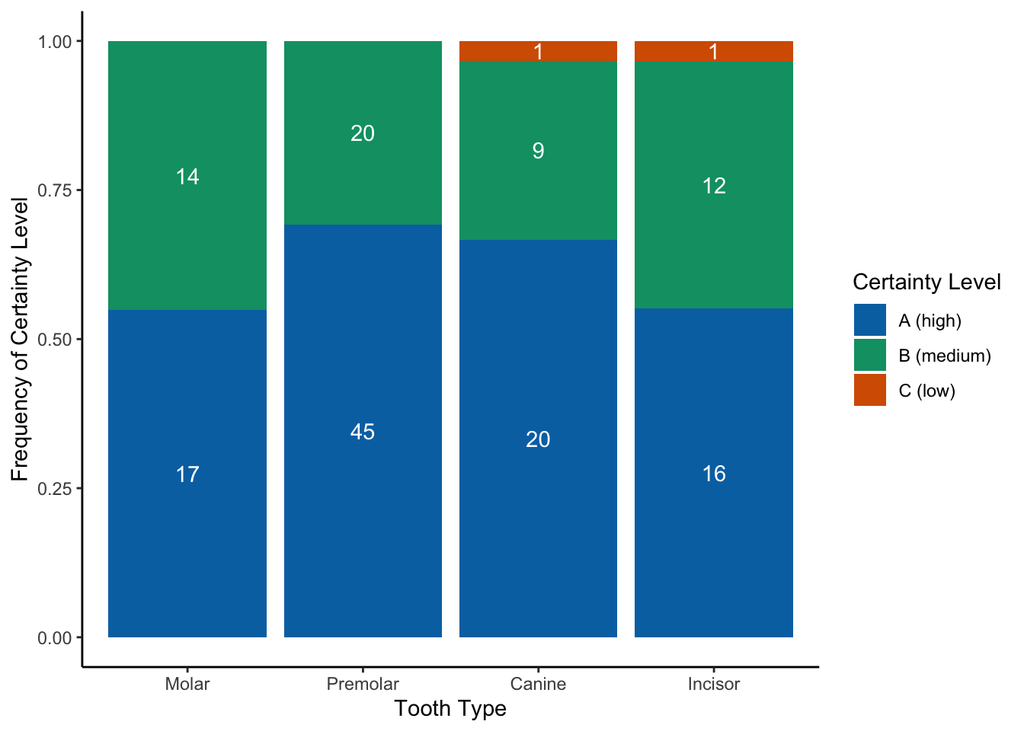

```r
###############################################################################
# Part 2: Certainty by Different Variables ##################################
###############################################################################

pal = c("A" = "#0072b2", "B" = "#009e73", "C" = "#d55e00")

# Certainty by tooth type plot and table ------------------------------------
tooth_type <- SEOT_teeth %>%
  group_by(tooth_category, certainty_code) %>%
  summarise(n=n()) %>%
  mutate(freq = n/sum(n), #calculate frequency of each certainty level
         tooth_category = factor(tooth_category, levels = c("M", "P", "C", "I")),
         certainty_code = factor(certainty_code, levels = c("C", "B", "A")),
         n_category = sum(n)) %>%
  ungroup() %>%
  filter(tooth_category != "UNK") #remove unknown teeth

ggplot(tooth_type, aes(x=tooth_category, y=freq))+
  geom_bar(aes(fill=certainty_code), position = "fill", stat='identity')+
  scale_fill_manual(values = pal, breaks = c("A", "B", "C"), labels = c("A (high)", "B (medium)", "C (low)"))+
  theme_classic()+
  labs(y="Frequency of Certainty Level", x="Tooth Type", fill = "Certainty Level")+
  geom_text(aes(label = paste(n), group = certainty_code), position = position_stack(vjust = 0.5), color = "white")+
  scale_x_discrete(labels = c("Molar", "Premolar", "Canine", "Incisor"))
```

2. **Area**

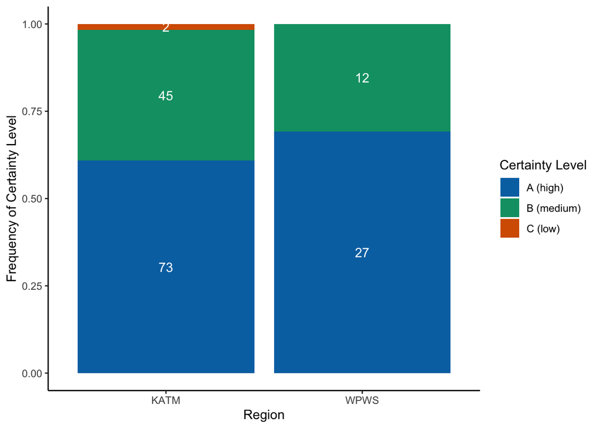

   ```r
   #Certainty by area ----------------------------------------------------------
   area <- SEOT_teeth %>%
     group_by(area, certainty_code) %>%
     summarise(n=n()) %>%
     mutate(freq = n/sum(n),
            n_area = sum(n),
            certainty_code = factor(certainty_code, levels = c("C", "B", "A"))) %>%
     ungroup()


   ggplot(area, aes(x=area, y=freq))+
     geom_bar(aes(fill=certainty_code), position = "fill", stat='identity')+
     scale_fill_manual(values = pal, breaks = c("A", "B", "C"), labels = c("A (high)", "B (medium)", "C (low)"))+
     theme_classic()+
     geom_text(aes(label = paste(n), group = certainty_code), position = position_stack(vjust = 0.5), color = "white")+
     labs(y="Frequency of Certainty Level", x="Region", fill = "Certainty Level")
   ```

3. **Year**

[figure not shown]

   ```r
   #Certainty by year ----------------------------------------------------------
   year <- SEOT_teeth %>%
     group_by(year, certainty_code) %>%
     summarise(n=n()) %>%
     mutate(freq = n/sum(n),
            year = as.character(year),
            certainty_code = factor(certainty_code, levels = c("C", "B", "A"))) %>%
     ungroup()

## 0.4 Assessing Drivers of Aging Precision

We started by measuring precision in two ways:

- probability that teeth from the same otter were given the same age via tooth cementum annuli analysis.
- probability that teeth from the same otter were given the same age class.

### How Does Precision Break Down by Predictor?

1. **Tooth Aging Certainty Score**

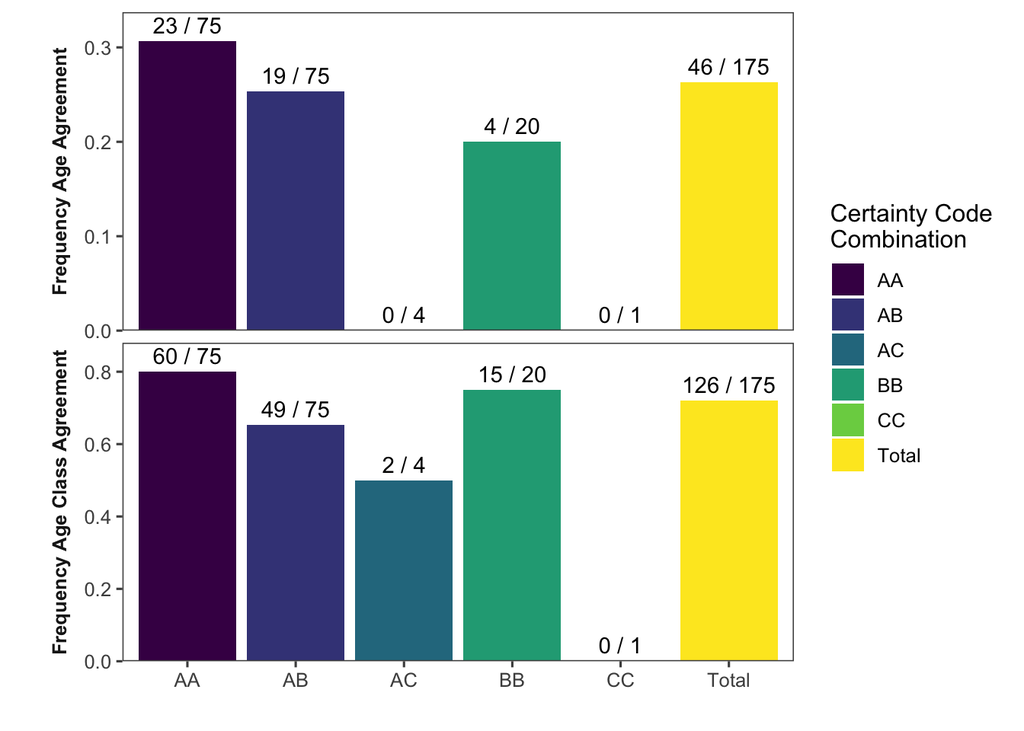

```r
###############################################################################
# Part 2: Precision by Different Variables ####################################
###############################################################################

tooth_comparison_certainty_summary <- tooth_age_comparison %>%
  group_by(certainty_code_combo) %>%
  summarise(n = n(),
            n_age_agreement = sum(age_agreement),
            n_age_class_agreement = sum(age_class_agreement)) %>%
  adorn_totals("row") %>%
  ungroup() %>%
  pivot_longer(cols = c(n_age_agreement, n_age_class_agreement))%>%
  mutate(freq= value/n)

fct_labels <- c("n_age_agreement" = "Frequency Age Agreement", "n_age_class_agreement" = "Frequency Age Class Agreement")


ggplot(tooth_comparison_certainty_summary, aes(certainty_code_combo, freq, fill = certainty_code_combo, label = paste(value, "/", n)))+
  geom_bar(stat='identity')+
  facet_grid(rows = "name", scales = "free", switch="y", labeller = as_labeller(fct_labels))+
  theme_few()+
  scale_fill_viridis_d()+
  geom_text(vjust = -0.5)+
  scale_y_continuous(expand = expansion(mult = c(0, 0.1)))+
  labs(y = "", x = "", fill = "Certainty Code \nCombination")+
  theme(strip.placement.y = "outside",
        strip.text.y = element_text(face = "bold"))
```

The above plot has certainty levels split by combinations of codes provided by Matsons labs. For example, “AA” indicated both teeth were assigned a certainty code of “A (high)”.

2. **Tooth Type Combinations**

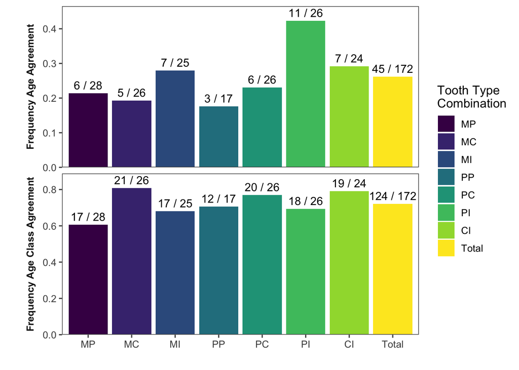

```r
# Tooth Type Combination ------------------------------------------------------

tooth_combo_certainty <- tooth_age_comparison %>%
  group_by(tooth_category_combo) %>%
  summarise(n = n(),
            n_age_agreement = sum(age_agreement),
            n_age_class_agreement = sum(age_class_agreement)) %>%
  mutate(tooth_category_combo = factor(tooth_category_combo,
                                             levels = c("MP","MC","MI","PP","PC","PI","CI","UNK"))) %>%
  filter(tooth_category_combo != "UNK") %>%
  adorn_totals("row") %>%
  ungroup() %>%
  pivot_longer(cols = c(n_age_agreement, n_age_class_agreement))%>%
  mutate(freq= value/n)



ggplot(tooth_combo_certainty, aes(tooth_category_combo, freq, fill = tooth_category_combo, label = paste(value, "/", n)))+
  geom_bar(stat='identity')+
  facet_grid(rows = "name", scales = "free", switch="y", labeller = as_labeller(fct_labels))+
  theme_few()+
  scale_fill_viridis_d()+
  geom_text(vjust = -0.5)+
  scale_y_continuous(expand = expansion(mult = c(0, 0.1)))+
  labs(y = "", x = "", fill = "Tooth Type \nCombination")+
  theme(strip.placement.y = "outside",
        strip.text.y = element_text(face = "bold"))
```

The plot above is split by combinations of tooth types. For example, “MP” indicates one tooth was a molar and one tooth was a premolar.

3. **Area**

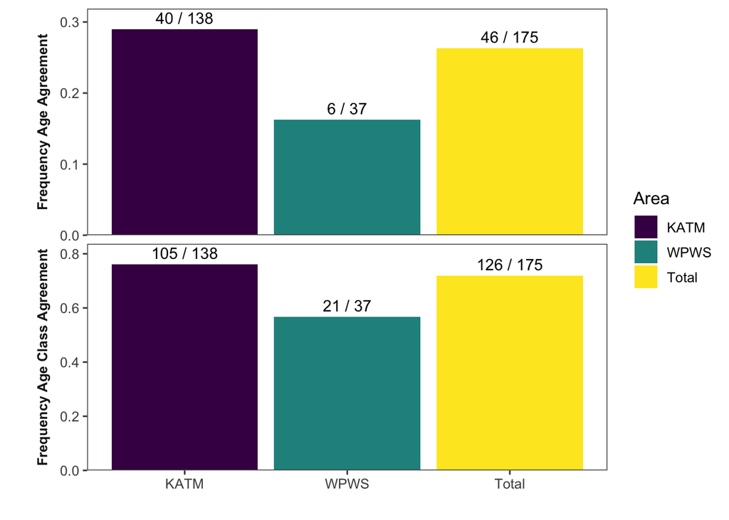

```r
area_certainty <- tooth_age_comparison %>%
  group_by(area) %>%
  summarise(n = n(),
            n_age_agreement = sum(age_agreement),
            n_age_class_agreement = sum(age_class_agreement)) %>%
  adorn_totals("row") %>%
  mutate(area = factor(area, levels = c("KATM", "WPWS", "Total"))) %>%
  ungroup() %>%
  pivot_longer(cols = c(n_age_agreement, n_age_class_agreement))%>%
  mutate(freq= value/n)



ggplot(area_certainty, aes(area, freq, fill = area, label = paste(value, "/", n)))+
  geom_bar(stat='identity')+
  facet_grid(rows = "name", scales = "free", switch="y", labeller = as_labeller(fct_labels))+
  theme_few()+
  scale_fill_viridis_d()+
  geom_text(vjust = -0.5)+
  scale_y_continuous(expand = expansion(mult = c(0, 0.1)))+
  labs(y = "", x = "", fill = "Area")+
  theme(strip.placement.y = "outside",
        strip.text.y = element_text(face = "bold"))
```

4. **Year**

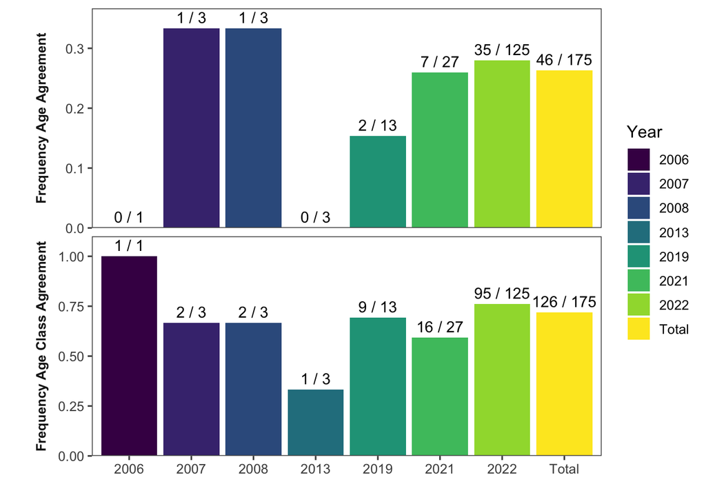

```r
# Year ------------------------------------------------------

year_certainty <- tooth_age_comparison %>%
  group_by(year) %>%
  summarise(n = n(),
            n_age_agreement = sum(age_agreement),
            n_age_class_agreement = sum(age_class_agreement)) %>%
  adorn_totals("row") %>%
  ungroup() %>%
  pivot_longer(cols = c(n_age_agreement, n_age_class_agreement))%>%
  mutate(freq= value/n)


ggplot(year_certainty, aes(year, freq, fill = year, label = paste(value, "/", n)))+
  geom_bar(stat='identity')+
  facet_grid(rows = "name", scales = "free", switch="y", labeller = as_labeller(fct_labels))+
  theme_few()+
  scale_fill_viridis_d()+
  geom_text(vjust = -0.5)+
  scale_y_continuous(expand = expansion(mult = c(0, 0.1)))+
  labs(y = "", x = "", fill = "Year")+
  theme(strip.placement.y = "outside",
        strip.text.y = element_text(face = "bold"))
```

### Alternative Measures of Precision: Age Difference

Perhaps frequency of age and/or age class agreement are not the best metrics of precision. It is likely that the frequency of age and age class agreement are influenced by multiple variables (for example, animal age).

To assess whether this is the case, lets look at the frequency of age and age class *disagreement* by the age of a randomly selected individual.

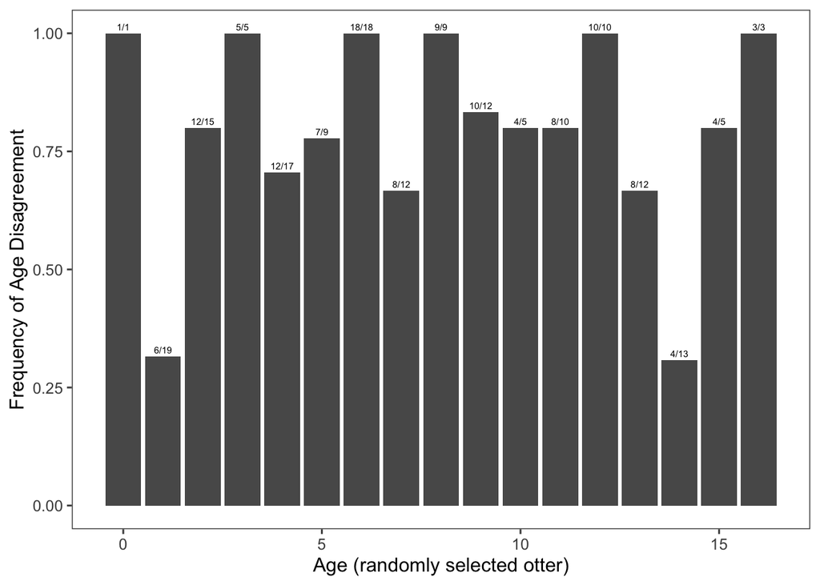

```r
probability_age_disagreement <- tooth_age_comparison %>%
  group_by(age1) %>%
  summarise(n = n(),
            n_disagreement = n()-sum(age_agreement),
            freq_disagreement = (n-sum(age_agreement))/n)

ggplot(probability_age_disagreement,
       aes(x=age1, y=freq_disagreement,
           label = paste0(n_disagreement, "/", n)))+
  geom_bar(stat = "identity")+
  theme_few()+
  geom_text(vjust = -0.5, size = 2)+
  labs(y="Frequency of Age Disagreement", x="Age (randomly selected otter)")
```

There is no obvious trend in age disagreement here, as far as I can tell. But let’s look at the frequency of age class disagreement:

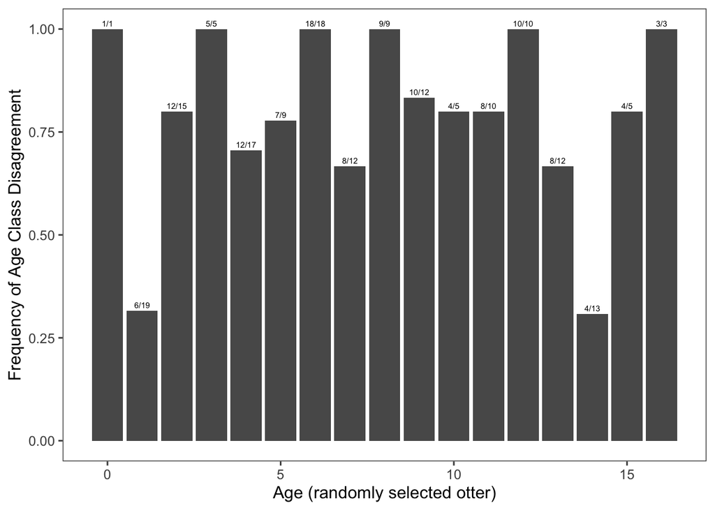

```r
probability_age_class_disagreement <- tooth_age_comparison %>%
  group_by(age1) %>%
  summarise(n = n(),
            n_disagreement = n()-sum(age_agreement),
            freq_disagreement = (n-sum(age_agreement))/n)

ggplot(probability_age_class_disagreement,
       aes(x=age1, y=freq_disagreement,
           label = paste0(n_disagreement, "/", n)))+
  geom_bar(stat = "identity")+
  theme_few()+
  geom_text(vjust = -0.5, size = 2)+
  labs(y="Frequency of Age Class Disagreement", x="Age (randomly selected otter)")
```

An alternative way to look at precision would be to examine the difference in ages (i.e., 1yr, 2yr, 3yr, etc.). This may be a useful way to break down the data, because we know that Matson’s labs tooth scoring does have different windows of certainty.

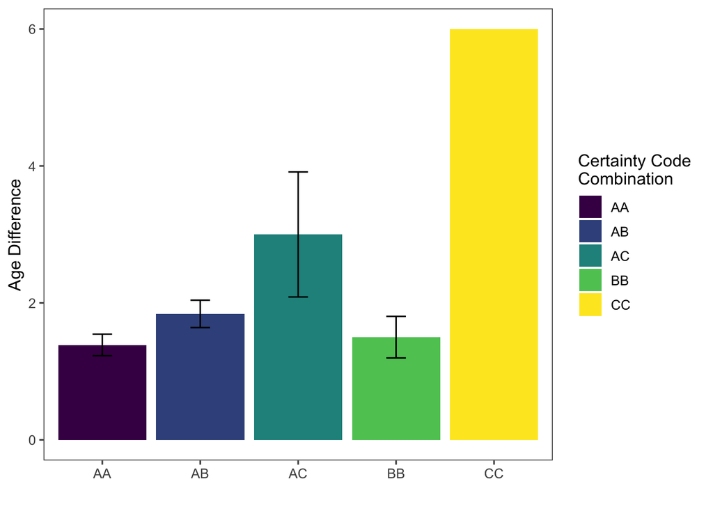

   ```r
   age_diff <- tooth_age_comparison %>%
     group_by(certainty_code_combo) %>%
     summarise(mean_diff = mean(age_diff),
            se_diff = sd(age_diff)/sqrt(length(age_diff)))

   ggplot(age_diff, aes(x=certainty_code_combo, y=mean_diff, fill = certainty_code_combo))+
     geom_bar(stat = "identity")+
     theme_few()+
     scale_fill_viridis_d()+
     geom_errorbar(aes(ymin = mean_diff-se_diff, ymax = mean_diff+se_diff, width = .2))+
     labs(y = "Age Difference", x = "",fill = "Certainty Code \nCombination")
   ```

   The values plotted above are the means ± SE. As we can see, the mean age differences for “AA”, “AB”, and “BB” are below 2. This is reassuring because Matson anticipates a ~1 year error for teeth with certainty score A and ~2 year error for teeth with certainty score B.
2. **Age Difference by Age**

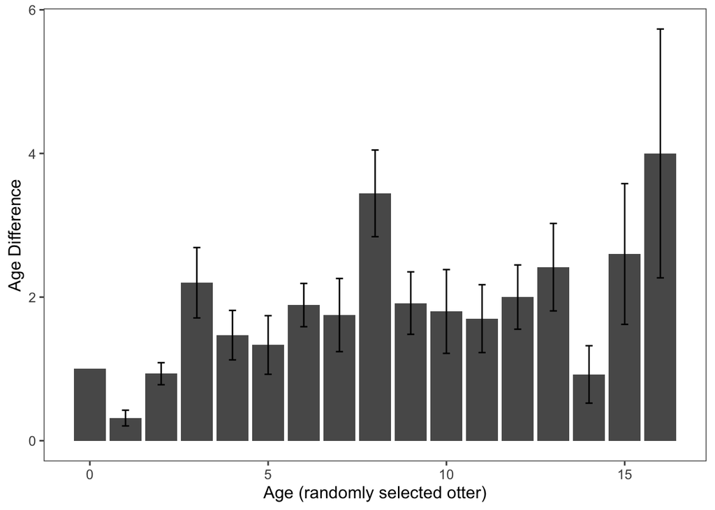

   ```r
   age_diff_by_age <- tooth_age_comparison %>%
     group_by(age1) %>%
     summarise(mean_diff = mean(age_diff),
               se_diff = sd(age_diff)/sqrt(length(age_diff)))

   ggplot(age_diff_by_age, aes(x=age1, y=mean_diff))+
     geom_bar(stat = "identity")+
     theme_few()+
     geom_errorbar(aes(ymin = mean_diff-se_diff, ymax = mean_diff+se_diff, width = .2))+
     labs(y = "Age Difference", x = "Age (randomly selected otter)")
   ```

   Again, these are means ± SEs plotted. Interestingly, there is less of a trend than I anticipated here (I expected the age difference to steadily increase with animal age). Though that trend is apparent, it doesn’t seem particularly striking.
3. Age Difference by Tooth Type

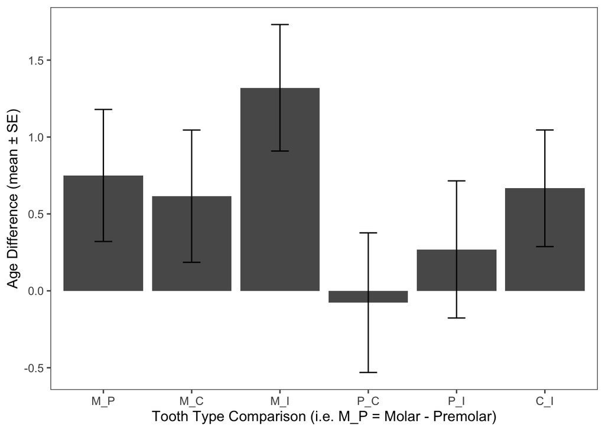

   ```r
   tooth_type_diff <- tooth_age_comparison %>%
     select(tooth_category1, tooth_category2, age1, age2) %>%
     filter(tooth_category1 != "UNK" & tooth_category2 != "UNK") %>%
     unite(tooth_cat_combo, c("tooth_category1","tooth_category2")) %>%
     mutate(tooth_cat_combo2 = if_else(tooth_cat_combo == "M_M"|
                                       tooth_cat_combo == "M_P"|
                                       tooth_cat_combo == "M_C"|
                                       tooth_cat_combo == "M_I"|
                                       tooth_cat_combo == "P_P"|
                                       tooth_cat_combo == "P_C"|
                                       tooth_cat_combo == "P_I"|
                                       tooth_cat_combo == "C_C"|
                                       tooth_cat_combo == "C_I"|
                                       tooth_cat_combo == "I_I",
                                       tooth_cat_combo,
                                       if_else(tooth_cat_combo == "P_M", "M_P",
                                       if_else(tooth_cat_combo == "C_M", "M_C",
                                       if_else(tooth_cat_combo == "C_P", "P_C",
                                       if_else(tooth_cat_combo == "I_P", "P_I",
                                       if_else(tooth_cat_combo == "I_M", "M_I",
                                       if_else(tooth_cat_combo == "I_C", "C_I", NA)))))))) %>%
     mutate(age3 = if_else(tooth_cat_combo==tooth_cat_combo2, age1, age2),
            age4 = if_else(tooth_cat_combo==tooth_cat_combo2, age2, age1)) %>%
     select(tooth_cat_combo = tooth_cat_combo2,
            age1 = age3,
            age2 = age4) %>%
     filter(tooth_cat_combo != "P_P") %>%
     mutate(age_diff = age1-age2) %>%
     group_by(tooth_cat_combo) %>%
     summarise(mean_age_diff = mean(age_diff),
               sd_age_diff = sd(age_diff),
            se_age_diff = sd(age_diff)/sqrt(n())) %>%
     mutate(tooth_cat_combo =
              factor(tooth_cat_combo,
                     levels = c("M_P", "M_C", "M_I", "P_C", "P_I", "C_I")))


   ggplot(tooth_type_diff, aes(x=tooth_cat_combo, y=mean_age_diff))+
     geom_bar(stat="identity")+
     theme_few()+
     geom_errorbar(aes(ymin = mean_age_diff-se_age_diff, ymax = mean_age_diff+se_age_diff), width = .2)+
     labs(y= "Age Difference (mean ± SE)", x="Tooth Type Comparison (i.e. M_P = Molar - Premolar)")
   ```

It appears that molars tend to be assigned a greater age than other tooth types, and incisors tend to be assigned a lower age than other tooth types. However, as these are means±SE (not SD), there is a lot of variation and these generalizations may not in fact hold true with a larger sample.